# Objective: To predict the concrete strength using the data available in file 'concrete.csv'. Apply feature engineering and model tuning to obtain a score above 85%.

## Exploratory Data Analysis (EDA) and Univariate Data Analysis

```python
# Import packages to use in EDA,
import numpy as np
import pandas as pd
import matplotlib.pyplot as plt
%matplotlib inline
import seaborn as sns
from sklearn.model_selection import KFold
from sklearn.model_selection import cross_val_score

from sklearn.ensemble import RandomForestRegressor
from sklearn.ensemble import BaggingRegressor
from xgboost import XGBRegressor

from imblearn.over_sampling import RandomOverSampler
from sklearn.preprocessing import PowerTransformer
from sklearn.preprocessing import MinMaxScaler
from sklearn.model_selection import train_test_split
from sklearn.model_selection import RandomizedSearchCV
```

```python
# Import data into pandas dataframe
data_og = pd.read_csv('concrete.csv')
```

```python
# Check number of columns in dataframe, 8 are dependent variables with 1 dependent variable "strength"
# Check number of records in the data, which is 1030
data_og.columns
```

```
Index(['cement', 'slag', 'ash', 'water', 'superplastic', 'coarseagg',
       'fineagg', 'age', 'strength'],
      dtype='object')
```

```python
# Print first 5 rows of the data
data_og.head()
```

|  | cement | slag | ash | water | superplastic | coarseagg | fineagg | age | strength |
| --- | --- | --- | --- | --- | --- | --- | --- | --- | --- |
| 0 | 141.3 | 212.0 | 0.0 | 203.5 | 0.0 | 971.8 | 748.5 | 28 | 29.89 |
| 1 | 168.9 | 42.2 | 124.3 | 158.3 | 10.8 | 1080.8 | 796.2 | 14 | 23.51 |
| 2 | 250.0 | 0.0 | 95.7 | 187.4 | 5.5 | 956.9 | 861.2 | 28 | 29.22 |
| 3 | 266.0 | 114.0 | 0.0 | 228.0 | 0.0 | 932.0 | 670.0 | 28 | 45.85 |
| 4 | 154.8 | 183.4 | 0.0 | 193.3 | 9.1 | 1047.4 | 696.7 | 28 | 18.29 |

```python
# Descriptive Stats of the variables
data_og.describe()
```

|  | cement | slag | ash | water | superplastic | coarseagg | fineagg | age | strength |
| --- | --- | --- | --- | --- | --- | --- | --- | --- | --- |
| count | 1030.000000 | 1030.000000 | 1030.000000 | 1030.000000 | 1030.000000 | 1030.000000 | 1030.000000 | 1030.000000 | 1030.000000 |
| mean | 281.167864 | 73.895825 | 54.188350 | 181.567282 | 6.204660 | 972.918932 | 773.580485 | 45.662136 | 35.817961 |
| std | 104.506364 | 86.279342 | 63.997004 | 21.354219 | 5.973841 | 77.753954 | 80.175980 | 63.169912 | 16.705742 |
| min | 102.000000 | 0.000000 | 0.000000 | 121.800000 | 0.000000 | 801.000000 | 594.000000 | 1.000000 | 2.330000 |
| 25% | 192.375000 | 0.000000 | 0.000000 | 164.900000 | 0.000000 | 932.000000 | 730.950000 | 7.000000 | 23.710000 |
| 50% | 272.900000 | 22.000000 | 0.000000 | 185.000000 | 6.400000 | 968.000000 | 779.500000 | 28.000000 | 34.445000 |
| 75% | 350.000000 | 142.950000 | 118.300000 | 192.000000 | 10.200000 | 1029.400000 | 824.000000 | 56.000000 | 46.135000 |
| max | 540.000000 | 359.400000 | 200.100000 | 247.000000 | 32.200000 | 1145.000000 | 992.600000 | 365.000000 | 82.600000 |

```python
# Check for NULL values, which there are none
data_og.isnull().values.any()
```

```
False
```

```python
# Check for duplicate records, which there are 25
data_og.duplicated().sum()
```

```
25
```

```python
# Drop duplicate records, and create new DataFrame without duplicate records
data = pd.DataFrame(data_og.drop_duplicates(inplace=False))
```

```python
data.shape
```

```
(1005, 9)
```

```python
# Check skewness of data
from scipy.stats import skew
for i in data.columns:
    print(data[i].name, 'skew =', skew(data[i]))
```

```
cement skew = 0.5641153988986095
slag skew = 0.8539479129539447
ash skew = 0.49648882209587886
water skew = 0.034381793851841036
superplastic skew = 0.9791401246984148
coarseagg skew = -0.06515856141355447
fineagg skew = -0.25197637809521817
age skew = 3.249115025189808
strength skew = 0.395105298044056
```

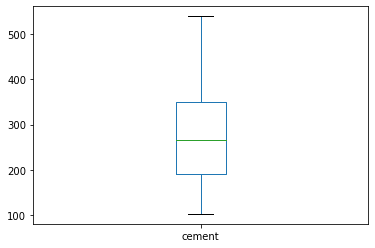

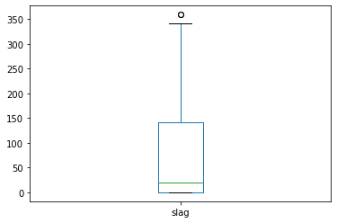

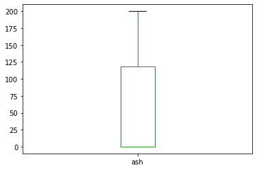

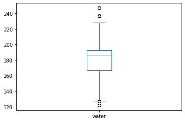

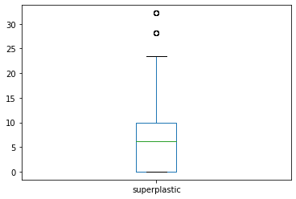

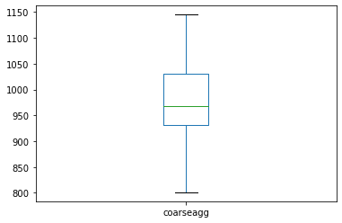

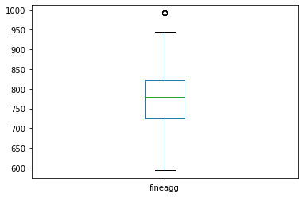

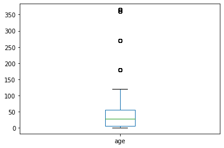

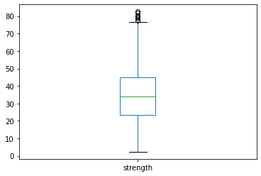

```python
# Plot Boxplots for independent variables
for i in data.columns:
    data[i].plot.box()
    plt.show()
    print('')
```

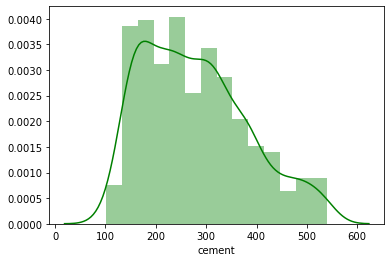

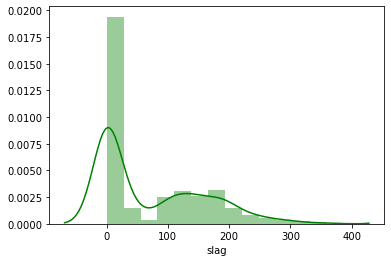

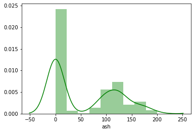

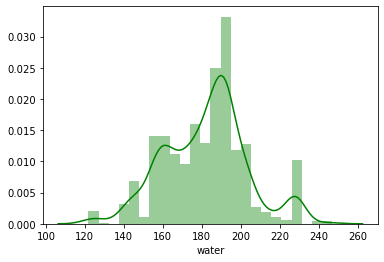

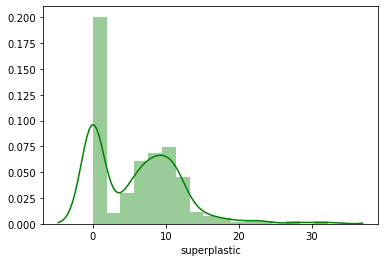

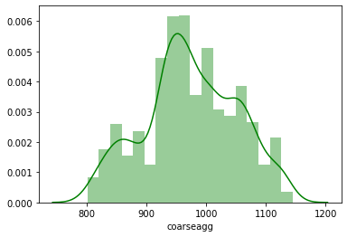

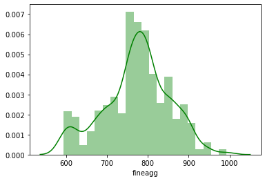

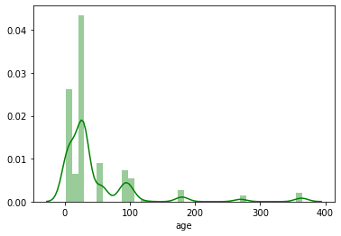

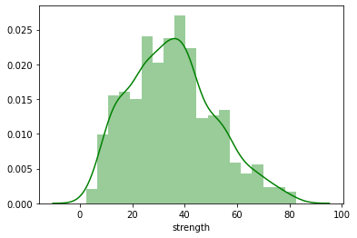

```python
# Plot Distplot (continuous variable)
for i in data.columns:
    sns.distplot(data[i], color='g')
    plt.show()
    print('')
```

#### Review of long tails and multiple peaks and valleys in distplots, could be due to:

- Inputting errors
- Mixing of gaussians

```python
print("Slag is used in concrete = {0}% of time".format(round(100 * data[data['slag'] > 0].shape[0] / data.shape[0])))
print("Ash is used in concrete = {0}% of time".format(round(100 * data[data['ash'] > 0].shape[0] / data.shape[0])))
print("Superplastic is used in concrete = {0}% of time".format(round(100 * data[data['superplastic'] > 0].shape[0] / data.shape[0])))
```

```
Slag is used in concrete = 53% of time
Ash is used in concrete = 46% of time
Superplastic is used in concrete = 62% of time
```

## Bivariate Analysis

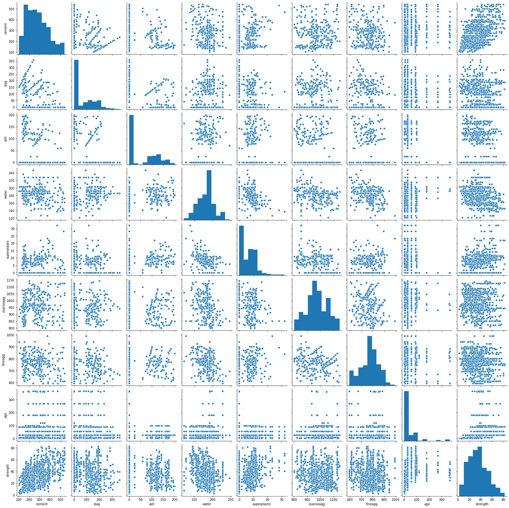

```python
# Plotting pair plots of continuous independent variables, as well as dependent variable
sns.pairplot(data);
```

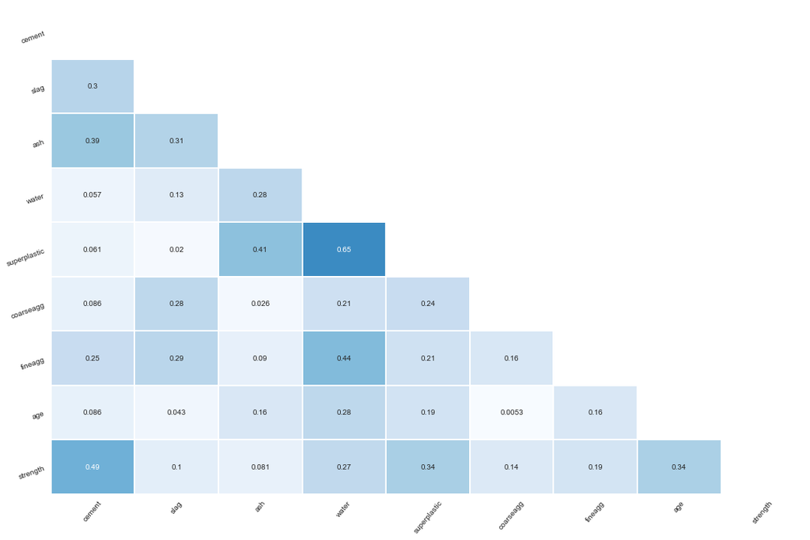

```python
corr = abs(data.corr()) # correlation matrix
lower_triangle = np.tril(corr, k = -1)  # select only the lower triangle of the correlation matrix
mask = lower_triangle == 0  # to mask the upper triangle in the following heatmap

plt.figure(figsize = (18,12))  # setting the figure size
sns.set_style(style = 'white')  # Setting it to white so that we do not see the grid lines
sns.heatmap(lower_triangle, center=0.5, cmap= 'Blues', annot= True, xticklabels = corr.index, yticklabels = corr.columns,
            cbar= False, linewidths= 1, mask = mask)   # Da Heatmap
plt.xticks(rotation = 50)   # Aesthetic purposes
plt.yticks(rotation = 20)   # Aesthetic purposes
plt.show()
```

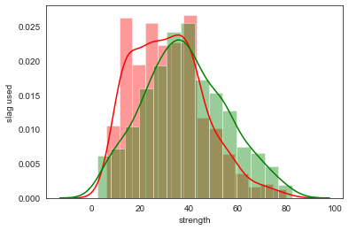

```python
# Bi-variate analysis - Plot Distplot strength & Crosstab slag
sns.distplot(data[data['slag']==0]['strength'],color='red',label='no')
sns.distplot(data[data['slag']>0]['strength'],color='green',label='yes')
plt.ylabel('slag used')
plt.show();
```

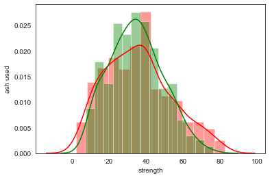

```python
# Bi-variate analysis - Plot Distplot strength & Crosstab ash
sns.distplot(data[data['ash']==0]['strength'],color='red',label='no')
sns.distplot(data[data['ash']>0]['strength'],color='green',label='yes')
plt.ylabel('ash used')
plt.show();
```

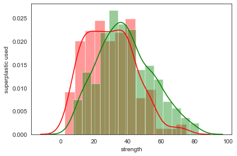

```python
# Bi-variate analysis - Plot Distplot strength & Crosstab superplastic
sns.distplot(data[data['superplastic']==0]['strength'],color='red',label='no')
sns.distplot(data[data['superplastic']>0]['strength'],color='green',label='yes')
plt.ylabel('superplastic used')
plt.show();
```

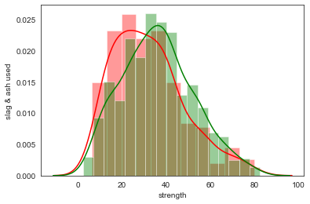

```python
# Bi-variate analysis - Plot Distplot strength & Crosstab slag & ash usage
sns.distplot(data[(data['slag']==0) & (data['ash']==0)]['strength'],color='red',label='no')
sns.distplot(data[(data['slag']>0) | data['ash']>0]['strength'],color='green',label='yes')
plt.ylabel('slag & ash used')
plt.show();
```

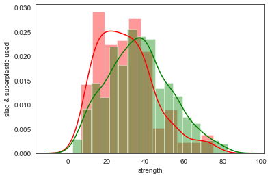

```python
# Bi-variate analysis - Plot Distplot strength & Crosstab slag & superplastic usage
sns.distplot(data[(data['slag']==0) & (data['superplastic']==0)]['strength'],color='red',label='no')
sns.distplot(data[(data['slag']>0) | data['superplastic']>0]['strength'],color='green',label='yes')
plt.ylabel('slag & superplastic used')
plt.show();
```

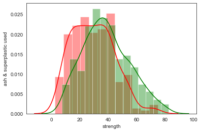

```python
# Bi-variate analysis - Plot Distplot strength & Crosstab ash & superplastic usage
sns.distplot(data[(data['ash']==0) & (data['superplastic']==0)]['strength'],color='red',label='no')
sns.distplot(data[(data['ash']>0) | data['superplastic']>0]['strength'],color='green',label='yes')
plt.ylabel('ash & superplastic used')
plt.show();
```

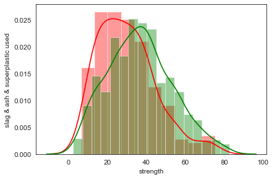

```python
# Bi-variate analysis - Plot Distplot strength & Crosstab slag & ash & superplastic usage
sns.distplot(data[(data['slag']==0) & (data['ash']==0) & (data['superplastic']==0)]['strength'],color='red',label='no')
sns.distplot(data[(data['slag']>0) | (data['ash']>0) | data['superplastic']>0]['strength'],color='green',label='yes')
plt.ylabel('slag & ash & superplastic used')
plt.show();
```

## Inference about the data analysis and write the recommendations

#### Zero minimum values in Slag, Ash, Superplastic:

- This is probably due to these components being optional in concrete, hence when zero I assume they are not used

#### Review of long tails and multiple peaks and valleys in distplots, could be due to:

- Inputting errors
- Mixing of gaussians, like types of concrete which use Slag and/or Ash and/or Superplastic

#### Types of concrete

- There appears to be different types of concrete, which may lead to different gaussians. The types are based on the input components whose permutations are:
  - Slag and Ash and Superplastic not used
  - Slag only is used out of "Slag and Ash and Superplastic"
  - Ash only is used out of "Slag and Ash and Superplastic"
  - Superplastic only is used out of "Slag and Ash and Superplastic"
  - Slag & Ash is used out of "Slag and Ash and Superplastic"
  - Slag & Superplastic is used out of "Slag and Ash and Superplastic"
  - Ash & Superplastic is used out of "Slag and Ash and Superplastic"
  - Slag and Ash and Superplastic are all used
- New binary (values 0 or 1) variables slag_used, ash_used & superplastic_used are used to try and differentiate the concrete types

#### Bi-variate analysis

- Distplot strength with Crosstab of "Slag and/or Ash and/or Superplastic" usage, shows a normal distribution of strength when "Slag and/or Ash and/or Superplastic" are used
- This means concrete has predictable strength when "Slag and/or Ash and/or Superplastic" are used vs when they are all not used

## Feature Engineering Techniques

```python
data.info()
```

```
<class 'pandas.core.frame.DataFrame'>
Int64Index: 1005 entries, 0 to 1029
Data columns (total 9 columns):
 #   Column        Non-Null Count  Dtype
---  ------        --------------  -----
 0   cement        1005 non-null   float64
 1   slag          1005 non-null   float64
 2   ash           1005 non-null   float64
 3   water         1005 non-null   float64
 4   superplastic  1005 non-null   float64
 5   coarseagg     1005 non-null   float64
 6   fineagg       1005 non-null   float64
 7   age           1005 non-null   int64
 8   strength      1005 non-null   float64
dtypes: float64(8), int64(1)
memory usage: 118.5 KB
```

#### Create matrix X1 and y

```python
# Create columns to track whether slag, ash or superplastic are used
count = 0

for index, row in data.iterrows():
    count+=1
    if row['slag'] > 0:
        data.loc[index,'slag_used'] = 1
    else:
        data.loc[index,'slag_used'] = 0
    if row['ash'] > 0:
        data.loc[index,'ash_used'] = 1
    else:
        data.loc[index,'ash_used'] = 0
    if row['superplastic'] > 0:
        data.loc[index,'superplastic_used'] = 1
    else:
        data.loc[index,'superplastic_used'] = 0

print ('Total records reviewed =', count)
```

```
Total records reviewed = 1005
```

```python
y = data['strength']
X1 = data.drop(['strength'], axis=1, inplace=False)
X1.info()
```

```
<class 'pandas.core.frame.DataFrame'>
Int64Index: 1005 entries, 0 to 1029
Data columns (total 11 columns):
 #   Column             Non-Null Count  Dtype
---  ------             --------------  -----
 0   cement             1005 non-null   float64
 1   slag               1005 non-null   float64
 2   ash                1005 non-null   float64
 3   water              1005 non-null   float64
 4   superplastic       1005 non-null   float64
 5   coarseagg          1005 non-null   float64
 6   fineagg            1005 non-null   float64
 7   age                1005 non-null   int64
 8   slag_used          1005 non-null   float64
 9   ash_used           1005 non-null   float64
 10  superplastic_used  1005 non-null   float64
dtypes: float64(10), int64(1)
memory usage: 134.2 KB
```

```python
# Generate and store Testing data: X1_test
X1_train, X1_test, y_train, y_test = train_test_split(X1, y, test_size=0.3, random_state=3)
```

```python
# Scale 'age' in testing data (X1_test) separately from 'age' in validation data (X1_train)
X1_test = pd.DataFrame(X1_test.copy())
powTrans = PowerTransformer(method='yeo-johnson', standardize=False) # support 0 & -ve
X1_test[['age']] = powTrans.fit_transform(X1_test[['age']])
```

```python
# Scale 'age' in validation data (X1_train) separately from 'age' in testing data (X1_test)
X1_train = pd.DataFrame(X1_train.copy())
powTrans = PowerTransformer(method='yeo-johnson', standardize=False) # support 0 & -ve
X1_train[['age']] = powTrans.fit_transform(X1_train[['age']])
```

## Create RandomForest Model Tune it using K-Fold Cross Validation on Validation Set

- RandomForest bagging ensemble is chosen because it:
  - Does not overfit data typically
  - Its ensembling capability with voting based on mode, yields more reliable results

```python
# Create Dataframe for analysis
resultsCV = pd.DataFrame(columns=['Model', 'Accuracy', 'Std_Dev'])
```

```python
kf_10 = KFold(n_splits=10, shuffle=True, random_state=3)
```

```python
rfreg = RandomForestRegressor(n_estimators = 25)
results = cross_val_score(rfreg, X1_train, y_train, cv=kf_10)
print (results)
print ('XGBoost Regressor: Accuracy = %.3f%%, Std_Dev = (%.3f%%)' % (results.mean()*100.0, results.std()*100.0))
resultsCV = resultsCV.append({'Model': 'rfreg', 'Accuracy': results.mean()*100.0, 'Std_Dev': results.std()*100.0}, ignore_index=True)
```

```
[0.891545   0.86388694 0.8895857  0.93030564 0.93006558 0.87301492
 0.92109807 0.87174103 0.83955881 0.86251043]
XGBoost Regressor: Accuracy = 88.733%, Std_Dev = (2.955%)
```

## Create Bagging Model Tune it using K-Fold Cross Validation on Validation Set

- Bagging ensemble is chosen because it:
  - Does not overfit data typically
  - Its ensembling capability with parallel model building

```python
bgreg = BaggingRegressor(n_estimators=25)
results = cross_val_score(bgreg, X1_train, y_train, cv=kf_10)
print (results)
print ('XGBoost Regressor: Accuracy = %.3f%%, Std_Dev = (%.3f%%)' % (results.mean()*100.0, results.std()*100.0))
resultsCV = resultsCV.append({'Model': 'bgreg', 'Accuracy': results.mean()*100.0, 'Std_Dev': results.std()*100.0}, ignore_index=True)
```

```
[0.90447427 0.87107241 0.89499485 0.92567446 0.92494938 0.8610367
 0.92971453 0.88986139 0.80950987 0.85252543]
XGBoost Regressor: Accuracy = 88.638%, Std_Dev = (3.641%)
```

## Create XGBoost Model Tune it using K-Fold Cross Validation on Validation Set

- XGBoost is chosen as its based on Gradient Boosting, which is inherently a regression model. Also:
  - its ability to improve model performace sequentially with adaptive weighting after each iteration
  - it is built model performance and computational speed
  - gbtree is used to compare it to other ensemble tree models (Random Forest and Bagging)

```python
xgbreg = XGBRegressor(n_estimators=25)
results = cross_val_score(xgbreg, X1_train, y_train, cv=kf_10)
print (results)
print ('XGBoost Regressor: Accuracy = %.3f%%, Std_Dev = (%.3f%%)' % (results.mean()*100.0, results.std()*100.0))
resultsCV = resultsCV.append({'Model': 'xgbreg', 'Accuracy': results.mean()*100.0, 'Std_Dev': results.std()*100.0}, ignore_index=True)
```

```
[0.89930352 0.90790481 0.91210276 0.93064713 0.94091673 0.88583679
 0.92503267 0.90033109 0.88699029 0.85381493]
XGBoost Regressor: Accuracy = 90.429%, Std_Dev = (2.402%)
```

## Further tuning of Hyperparameters using RandomSearch

```python
resultsCV.head().sort_values(by=['Accuracy'], ascending=False)
```

|  | Model | Accuracy | Std_Dev |
| --- | --- | --- | --- |
| 2 | xgbreg | 90.428807 | 2.401802 |
| 0 | rfreg | 88.733121 | 2.954993 |
| 1 | bgreg | 88.638133 | 3.640745 |

#### RandomizedSearchCV on XGBoost model which has highest accuracy

```python
# Specify parameters and distributions to sample from
param_gridXGB = {'booster': ['gbtree'],
                 'learning_rate': np.arange(0.1,1,0.1),
                 'n_estimators': [50, 75, 100, 125, 150, 175, 200],
                 'max_depth': np.arange(1,15,2),
                 'reg_lambda': np.arange(0.1,0.9,0.05),
                 'reg_alpha': np.arange(0.1,0.9,0.05)}
```

```python
xgbreg = XGBRegressor()
randCV = RandomizedSearchCV(estimator=xgbreg, param_distributions=param_gridXGB, cv=kf_10, n_iter=200, random_state= 3, n_jobs=-1)
```

```python
randCV.fit(X1_train, y_train)
```

```
RandomizedSearchCV(cv=KFold(n_splits=10, random_state=3, shuffle=True),
                   estimator=XGBRegressor(base_score=None, booster=None,
                                          colsample_bylevel=None,
                                          colsample_bynode=None,
                                          colsample_bytree=None, gamma=None,
                                          gpu_id=None, importance_type='gain',
                                          interaction_constraints=None,
                                          learning_rate=None,
                                          max_delta_step=None, max_depth=None,
                                          min_child_weight=None, missing=nan...
                   param_distributions={'booster': ['gbtree'],
                                        'learning_rate': array([0.1, 0.2, 0.3, 0.4, 0.5, 0.6, 0.7, 0.8, 0.9]),
                                        'max_depth': array([ 1,  3,  5,  7,  9, 11, 13]),
                                        'n_estimators': [50, 75, 100, 125, 150,
                                                         175, 200],
                                        'reg_alpha': array([0.1 , 0.15, 0.2 , 0.25, 0.3 , 0.35, 0.4 , 0.45, 0.5 , 0.55, 0.6 ,
       0.65, 0.7 , 0.75, 0.8 , 0.85]),
                                        'reg_lambda': array([0.1 , 0.15, 0.2 , 0.25, 0.3 , 0.35, 0.4 , 0.45, 0.5 , 0.55, 0.6 ,
       0.65, 0.7 , 0.75, 0.8 , 0.85])},
                   random_state=3)
```

```python
# GridSearchCV best parameters
randCV.best_params_
```

```
{'reg_lambda': 0.6500000000000001,
 'reg_alpha': 0.8000000000000002,
 'n_estimators': 150,
 'max_depth': 5,
 'learning_rate': 0.2,
 'booster': 'gbtree'}
```

```python
xgbreg = XGBRegressor(booster='gbtree', n_estimators = 150, reg_lambda=0.65, reg_alpha=0.8, max_depth=5, learning_rate=0.2, n_jobs=-1)
```

## Significance of the R2 score from the business perspective

```python
results = cross_val_score(xgbreg, X1_train, y_train, cv=kf_10)
print (results)
print ('XGBoost Regressor: Accuracy = %.3f%%, Std_Dev = (%.3f%%)' % (results.mean()*100.0, results.std()*100.0))
```

```
[0.93973816 0.91247206 0.9353389  0.93069185 0.94428463 0.89679432
 0.94288347 0.932555   0.88846177 0.85803351]
XGBoost Regressor: Accuracy = 91.813%, Std_Dev = (2.721%)
```

```python
print('95% Confidence Interval = ',(results.mean()*100.0 - (1.96*results.std()*100.0)), 'to', (results.mean()*100.0 + (1.96*results.std()*100.0)))
```

```
95% Confidence Interval =  86.47904770019726 to 97.14602565800696
```

1. Average validation accuracy of the model is 91.8% with Std_Dev of 2.7% on validation data
2. There is a 95% chance that in production the accuracy of the model will fall between 86.5% and 97.1%
3. The model has an accuracy of 90.4% on test data (below), and likely to generalise decently in production

## Testing Score (on Test set)

```python
xgbreg.fit(X1_train, y_train)
score = xgbreg.score(X1_test, y_test)
print('Testing score on X1_test=', score)
```

```
Testing score on X1_test= 0.9039799800365941
```